[figure not shown]

# Tutoriel / Créer un thème MapContrib

À l’instar d’[OpenBeerMap](http://openbeermap.github.io), d’[OsmHydrant](http://osmhydrant.org/) et de [wheelmap](https://wheelmap.org), MapContrib vise à faciliter la contribution à OpenStreetMap, par la création de thèmes en fonction des TOC (Troubles Obsessionnels Cartographiques) propre à chacun. Ces thèmes se basent sur : - une requête overpass (technique pour aller interroger une copie synchronisée de la base de donnée OpenStreetMap), - la définition de “types de noeuds”,

Ce tutoriel vise à accompagner la création d’un thème. Les pré-requis pour pouvoir le faire sont :

- l’envie et/ou le besoin,
- [un compte OpenStreetMap](https://www.openstreetmap.org/user/new),
- connaître les tags (clé / valeur) dans [l’ontologie OpenStreetMap](https://wiki.openstreetmap.org/wiki/FR:Page_principale),
- connaître une requête [OverPass](http://overpass-turbo.eu/),

Quelques conseils !!!

- `Bien "penser" à ce que l'on veut voir, améliorer, ajouter avant de se lancer dans la requête, les tags, les modèles, la traduction !`,
- `Connaître les tags OpenStreetMap et avoir un peu regardé les différents cas sur le wiki`,
- `Commencer par un thème simple et une requête facile`

## Se rendre sur l’instance

- Pour ce tutoriel, l’instance utilisée est https://mapcontrib.xyz.

[figure not shown]

Page d’accueil

## Se connecter avec son compte OpenStreetMap

- Se rendre dans la colonne de paramètres,
- Se connecter en utilisant son compte OpenStreetMap,
- Accepter que MapContrib accède à votre compte OpenStreetMap,

### En images

[figure not shown]

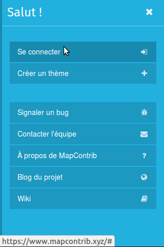

[figure not shown]

[figure not shown]

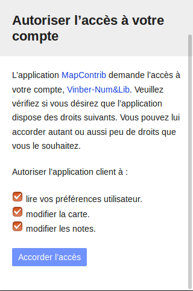

## Créer un nouveau thème

- Se rendre dans la colonne de paramètres,

[figure not shown]

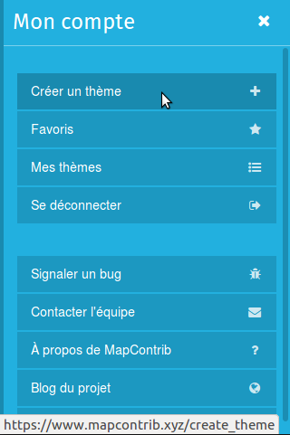

À noter :

- la possibilité de retrouver tous les thèmes que l’on a créé,
- la possibilité de retrouver ses favoris (des thèmes que l’on a créé ou pas, dont on souhaite garder la trace),

## Configurer le thème

Un thème porte un titre, peut s’ouvrir sur un territoire particulier et possède quelques options générales décrites ci-dessous. Toutes ses options sont modifiables par la suite.

### Trouver un lieu

- la `loupe` ou au clavier `Ctrl+f`

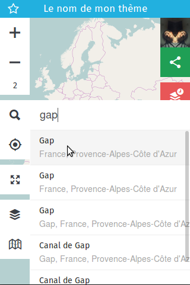

Rechercher un lieu

### Configuration

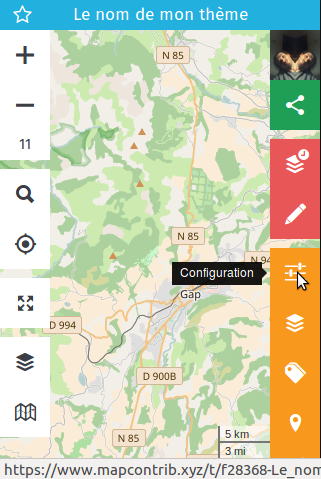

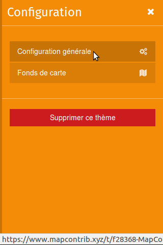

#### Nom du thème, description et couleurs

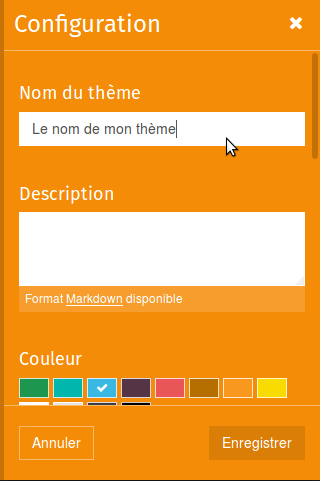

Colonne configuration générale - partie 1

- `Nom du thème` / apparaît à la fois dans l’url et en haut du thème
- si vous changez le titre, même une ancienne url fonctionne car le titre n’est pas pris en compte, seul le code (unique) sert à trouver le thème,
- pas d’inquiétudes donc vous pouvez changer le nom de votre thème quand vous voulez :)
- `Description` / permet de décrire le sujet de votre thème. Lorsque ce champ est rempli, un i apparaît à coté du nom du thème et permet d’accéder à la description.

[figure not shown]

Colonne configuration générale - partie 1-3

#### Positionnement et géolocalisation

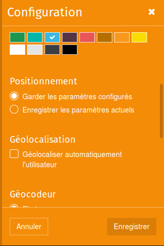

Colonne configuration générale - partie 2

- `Positionnement` / Enregistrer les paramètres actuels / permet de conserver la géolocalisation et le niveau de zoom pour une personne arrivant sur le thème,
- `Géolocalisation` / va demander l’autorisation de se géolocaliser à toute personne arrivant sur le thème,

#### Géocodeur, Affichage des informations et Statistiques

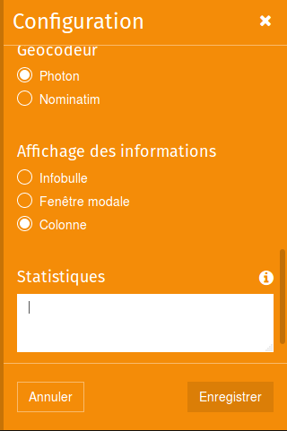

Colonne configuration générale - partie 3

- `Géocodeur` / permet de définir le géocodeur utilisé lors des recherche (`Ctrl+f`). Par défaut, Photon est utilisé pour des raisons de fluidité.
- `Affichage des informations` / les informations des POI peuvent être affichées dans plusieurs types de fenêtres. Par défaut en colonne à droite, il est aussi possible de changer le comportement du thème en affichant :
- des `Infobulles` / des `fenêtres modales`

[figure not shown]

[figure not shown]

### Fonds de carte

Cela permet de définir les fonds de cartes mis en avant par le créateur du thème. Les contributeurs auront cependant la possibilité d’en choisir d’autres, ceux définis par le créateur du thème sont simplement mis en avant.

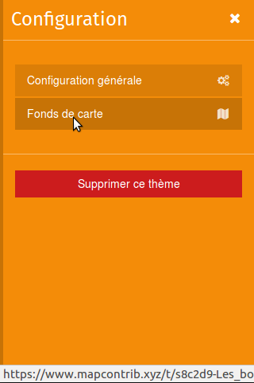

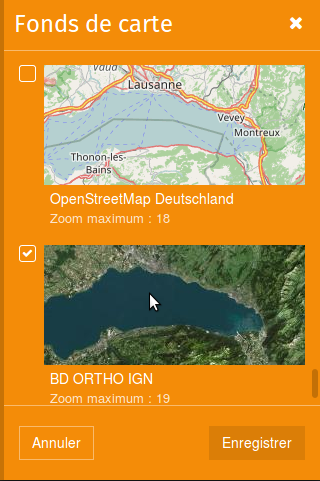

## Créer une couche de données

Plusieurs couches de données peuvent être créées. Cependant, quelques précautions avant de créer une dizaine de couches différentes: - dans les cas des couches “overpass” : **trop de couches simultanées renvoient des erreurs, les serveurs overpass n’appréciant pas d’avoir trop de requêtes provenant d’une même adresse “IP”**, - dans les cas d’autres types de couches : **trop de données peuvent aussi saturer l’explorateur internet, c’est coté client que se passe les calculs !**

Donc 4 types de données peuvent être ajoutés : - des données provenant directement d’OpenStreetMap à travers une requête overpass (c’est le coeur de MapContrib),

Mais aussi pour permettre de faire des comparaisons avec les données OSM : - des données dans un fichier csv comportant des titres de colonnes longitude et latitude, - par un fichier GeoJSON, - par un fichier GPX,

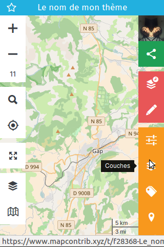

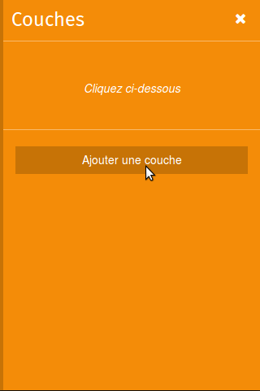

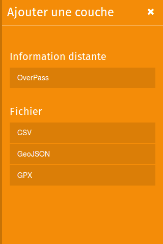

### Nom, Description et Visibilité

- `Nom` / définit le nom de cette couche, telle que cela apparaît pour les contributeurs,
- `Description` / permet de mieux renseigner le contenu de la couche -> supporte le markdown !
  - exemple ci-dessous de l’insertion d’une image,
- `Visibilité` / va permettre au créateur de thème de préparer de nouvelles couches mais de ne pas les montrer aux contributeurs sur le thème,

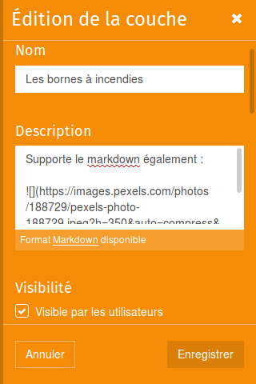

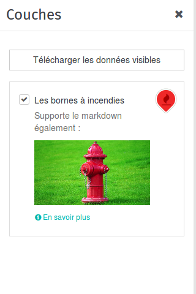